# Implications of animal movement rate variation in spatial patterns of seed dispersal

Javiera Rudolph

8/12/2021

Let’s say there is a variation in animal movement rates, and it depends on multiple factors, such as size of the animal, breeding status, nesting, etc. So, it can also be seasonal. Since movement rates can’t really be negative, we will use a lognormal distribution to describe this variation in movement rates among individuals from a population.

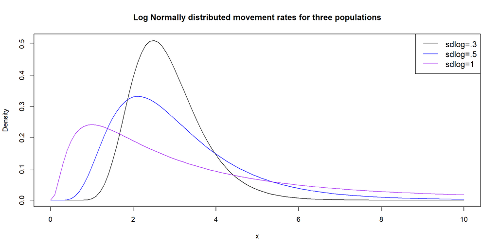

Now, lets sample a movement rate, $m$, for 5 individuals $(i.e. j = 1, ...,5)$ from the first population $(i.e. m_{1,j} = m_{1,1}, ....., m_{1,5})$. We will simulate animal movement with a simple random walk, with movement length $l$ sampled from an exponential distribution, $l \sim exp(m_{i,j})$, and movement angle, $\theta$, from a uniform distribution, $\theta \sim U(0, 360)$.

We can look at how those exponential distributions look for each of the individuals in those populations. Each curve describes the distribution of movement lengths for each of the five individuals in the population. Each panel represents one of the populations.

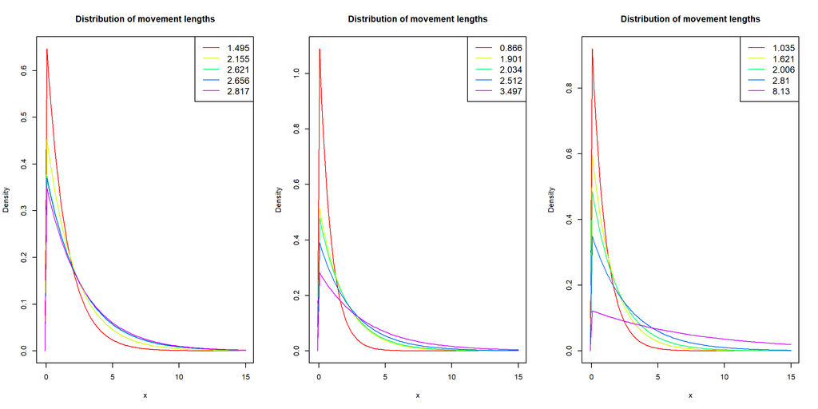

## Individual movement

For each population, we can simulate the movement of every individual using a random walk. Colors correspond to the individuals in the plot above. Every individual is sorted based on their average movement rate, so that the first individuals, colored in red, correspond to the smallest movement rate. In contrast, individuals described by violet correspond to the individuals with the highest movement rate in that population.

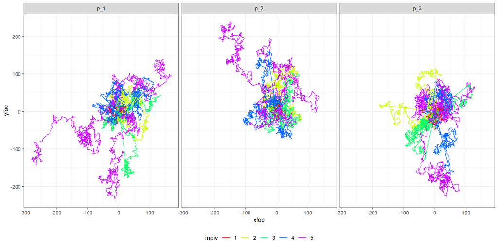

## Example individual

### Simulate movement and seed droppings

Now, we get the animals to disperse seeds. To do this, we combine seed gut retention times and animal movement. We can visualize this for one individual. Each simulation run consists of the animal disperser starting at point (0,0) and getting a number of seeds, each of which has an associated gut retention time $(grt \sim Gamma(4,5))$. The simulation run ends once all seeds have dropped. For that run, we calculate the average seed location by taking the average of x and y coordinates of all seeds. We also calculate seed dispersion as a measure of how close to each other or how scattered the seeds are for that run.

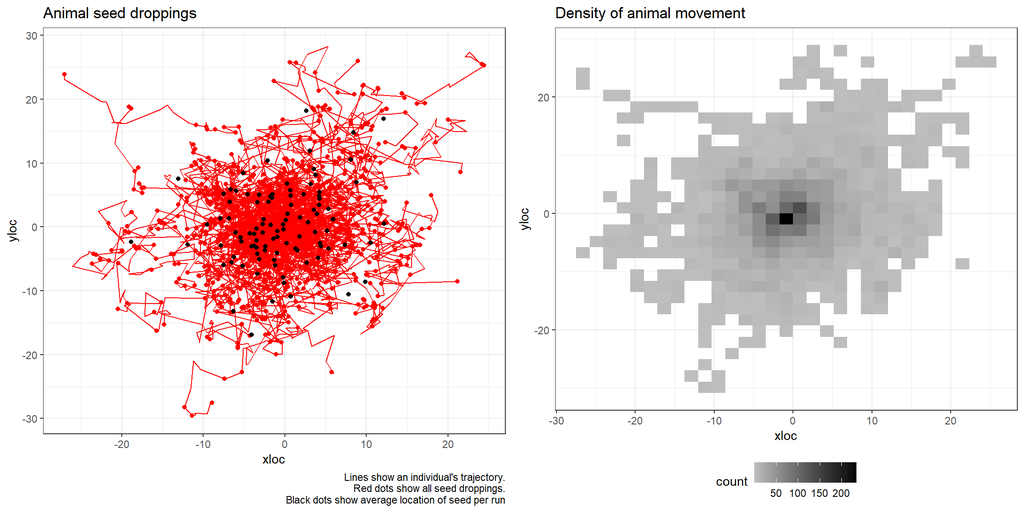

### Fit distribution function to seed dispersal data

The end goal here is to understand how variation in animal movement rates can impact seed dispersal patterns. To get a metric of this seed dispersal, we fit a weibull distribution to the seed dispersal data generated by the previous simulation. Every run has 20 seeds, and we did this 100 times, thus we randomly sample 50 seeds to fit a Weibull distribution and get an approximated seed dispersal kernel.

```
## Fitting of the distribution ' weibull ' by maximum likelihood
## Parameters :
##       estimate Std. Error
## shape 1.675391  0.1818627
## scale 8.029188  0.7177474
## Loglikelihood:  -139.3527   AIC:  282.7055   BIC:  286.5295
## Correlation matrix:
##           shape     scale
## shape 1.0000000 0.3294044
## scale 0.3294044 1.0000000
```

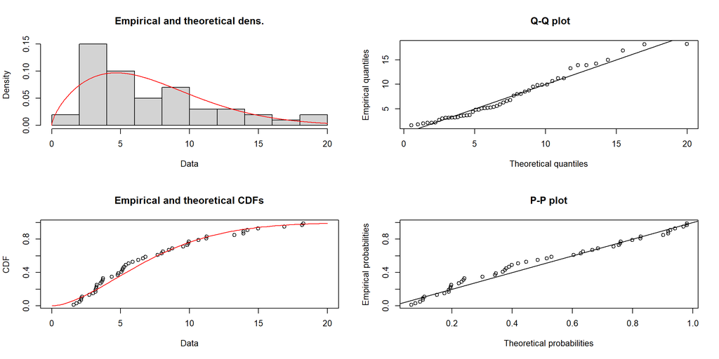

# Simulation for population 1

Visualize animal movement and seed dispersal. It is kind of obvious, but individuals that move further away, also disperse seeds further away and scatter them more. Red points are every seed dispersed, black points show the average seed location per run. Each panel corresponds to one individual disperser.

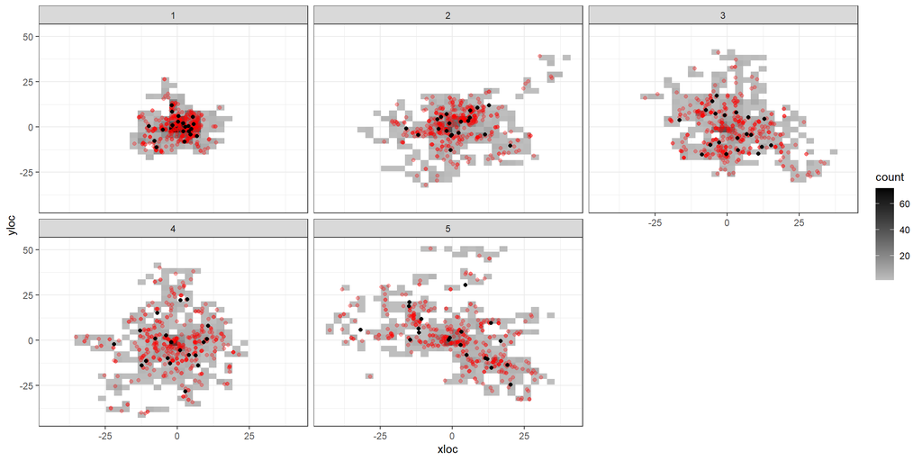

Seed dispersal kernels produced by each individual.

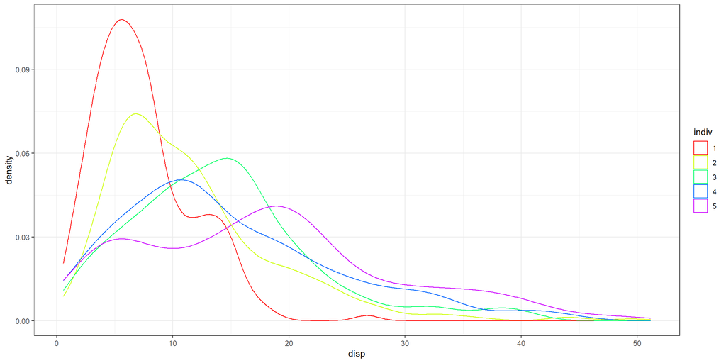

Dispersion. We calculate dispersion for every simulated run. Every run means an individual disperser gets 20 seeds, they move until they drop all seeds. Then, dispersion measures how far away from each other every seed is.

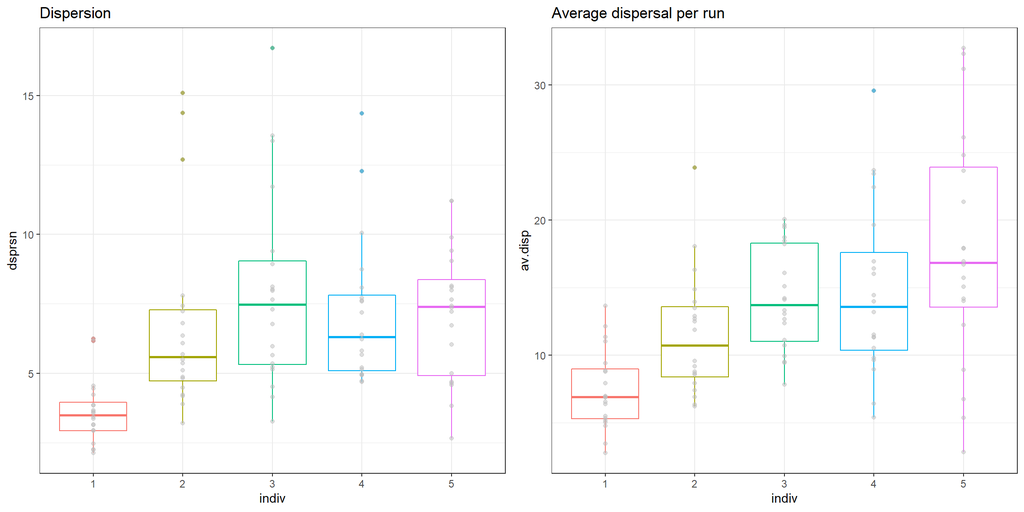

Bootstrapping?  
Since there are hundreds or thousands of seeds getting dispersed between all the simulations, we will randomly sample seeds and fit a weibull distribution to generate the seed dispersal kernels. The visualization shows the parameters estimated for each bootstrap, for each individual (no pooling) or when we pool all the seed dispersal data (complete pooling).

**What happens when we do complete pooling of the data instead of analyzing the variation by individuals. If instead we take all seed dispersal data and randomly sample seeds, and fit a Weibull kernel?** This is the comparisson between pooling or no pooling of seed dispersal data.

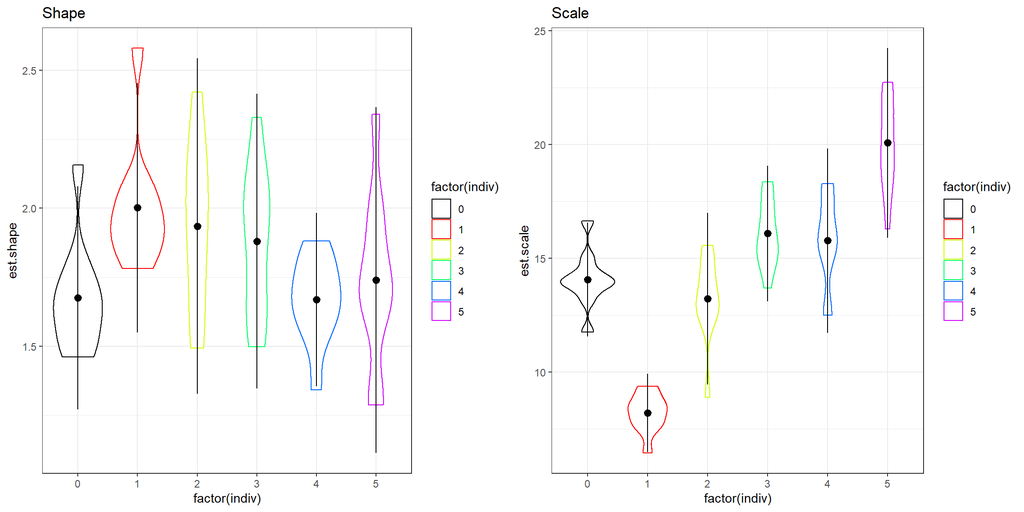

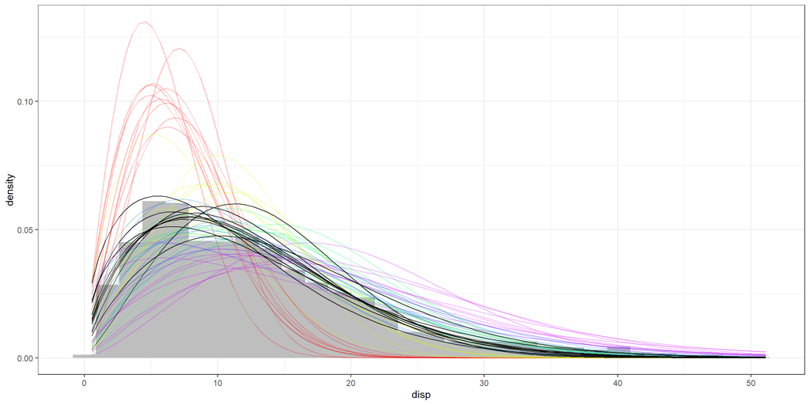

This is only an example for the first population, but the overall idea is that if an individual has a larger movement rate, it moves more and this tends to translate into moving further away. As a consequence, the individuals with higher movement rates disperse seeds farther away and more scattered, in comparison to individuals with lower movement rates. Thus, the seed dispersal kernels produced by these individuals also show this trend, where individuals with higher movement rates disperse seeds further. This shows with the fatter tails of the kernels, evidenced by the larger scale parameters from fitted Weibull distributions. When we pool the seed dispersal data, we ignore individual differences in how each disperser moved the seeds, and we estimate a seed dispersal kernel for that whole population or group.

## Comparisson of seed dispersal kernels across populations

These populations all have the same average movement rates, but their variance is different. This means that in the first population, all individuals have relatively similar movement rates, whereas in the third population, there is a lot more variation among the movement rates of individuals.

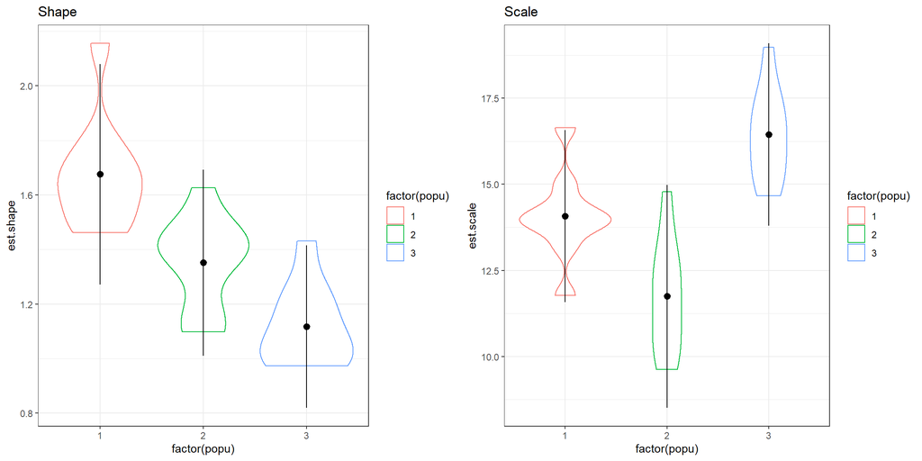